# HW 10

Jillian Egland

2023-04-19

## check 04_maps.Rmd?

## Homework 10

team: Jillian Egland https://github.com/jcegland/DS202-Spring2023

## Read in data

```r
library(tidyverse)
accident = read.csv("https://raw.githubusercontent.com/yumouqiu/DS202-Spring2023/main/Practice/data/fars2016/accident.csv")
person = read.csv("https://raw.githubusercontent.com/yumouqiu/DS202-Spring2023/main/Practice/data/fars2016/person.csv")
vehicle = read.csv("https://raw.githubusercontent.com/yumouqiu/DS202-Spring2023/main/Practice/data/fars2016/vehicle.csv")

head(accident)
```

```
##   STATE ST_CASE VE_TOTAL VE_FORMS PVH_INVL PEDS PERNOTMVIT PERMVIT PERSONS
## 1     1   10001        1        1        0    0          0       1       1
## 2     1   10002        1        1        0    0          0       2       2
## 3     1   10003        2        1        1    0          1       1       2
## 4     1   10004        1        1        0    0          0       1       1
## 5     1   10005        1        1        0    0          0       1       1
## 6     1   10006        1        1        0    0          0       1       1
##   COUNTY CITY DAY MONTH YEAR DAY_WEEK HOUR MINUTE NHS RUR_URB FUNC_SYS RD_OWNER
## 1     73 1716   1     1 2016        6    9     25   1       2        1        1
## 2     73 1716  10     1 2016        1   19     59   1       2        1        1
## 3     73    0   1     1 2016        6    2     20   1       1        1        1
## 4     73    0  17     1 2016        1   21     45   1       1        1        1
## 5     73 3125  26     1 2016        3   20      7   1       2        1        1
## 6    109    0   1     1 2016        6    1     10   0       1        4        1
##   ROUTE TWAY_ID   TWAY_ID2 MILEPT LATITUDE  LONGITUD SP_JUR HARM_EV MAN_COLL
```

[output cut: 27 more lines]

```r
head(person)
```

```
##   STATE ST_CASE VE_FORMS VEH_NO PER_NO STR_VEH COUNTY DAY MONTH HOUR MINUTE
## 1     1   10001        1      1      1       0     73   1     1    9     25
## 2     1   10002        1      1      1       0     73  10     1   19     59
## 3     1   10002        1      1      2       0     73  10     1   19     59
## 4     1   10003        1      1      1       0     73   1     1    2     20
## 5     1   10003        1      2      1       0     73   1     1    2     20
## 6     1   10004        1      1      1       0     73  17     1   21     45
##   RUR_URB FUNC_SYS HARM_EV MAN_COLL SCH_BUS MAKE MAK_MOD BODY_TYP MOD_YEAR
## 1       2        1      42        0       0   20   20401       14     2002
## 2       2        1       1        0       0   37   37031        4     2008
## 3       2        1       1        0       0   37   37031        4     2008
## 4       1        1      14        0       0   20   20481       31     2008
## 5       1        1      14        0       0   82   82881       66     2016
## 6       1        1      25        0       0   20   20481       31     2000
##   TOW_VEH SPEC_USE EMER_USE ROLLOVER IMPACT1 FIRE_EXP AGE SEX PER_TYP INJ_SEV
```

[output cut: 41 more lines]

```r
head(vehicle)
```

```
##   STATE ST_CASE VEH_NO VE_FORMS NUMOCCS DAY MONTH HOUR MINUTE HARM_EV MAN_COLL
## 1     1   10001      1        1       1   1     1    9     25      42        0
## 2     1   10002      1        1       2  10     1   19     59       1        0
## 3     1   10003      1        1       1   1     1    2     20      14        0
## 4     1   10004      1        1       1  17     1   21     45      25        0
## 5     1   10005      1        1       1  26     1   20      7      42        0
## 6     1   10006      1        1       1   1     1    1     10      42        0
##   UNITTYPE HIT_RUN REG_STAT OWNER MAKE MODEL MAK_MOD BODY_TYP MOD_YEAR
## 1        1       0        1     2   20   401   20401       14     2002
## 2        1       0        1     1   37    31   37031        4     2008
## 3        1       0        1     1   20   481   20481       31     2008
## 4        1       0        1     1   20   481   20481       31     2000
## 5        1       0        1     3   20   481   20481       31     1995
## 6        1       0        1     1   49   472   49472       30     2009
##            VIN VIN_1 VIN_2 VIN_3 VIN_4 VIN_5 VIN_6 VIN_7 VIN_8 VIN_9 VIN_10
```

[output cut: 69 more lines]

# plotting lat and long on map

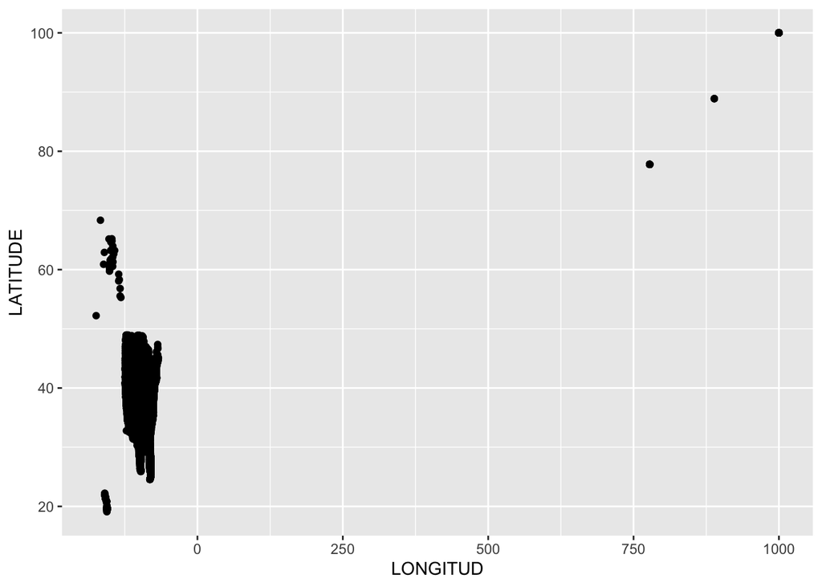

```r
ggplot(accident, aes(x=LONGITUD, y=LATITUDE)) + geom_point()
```

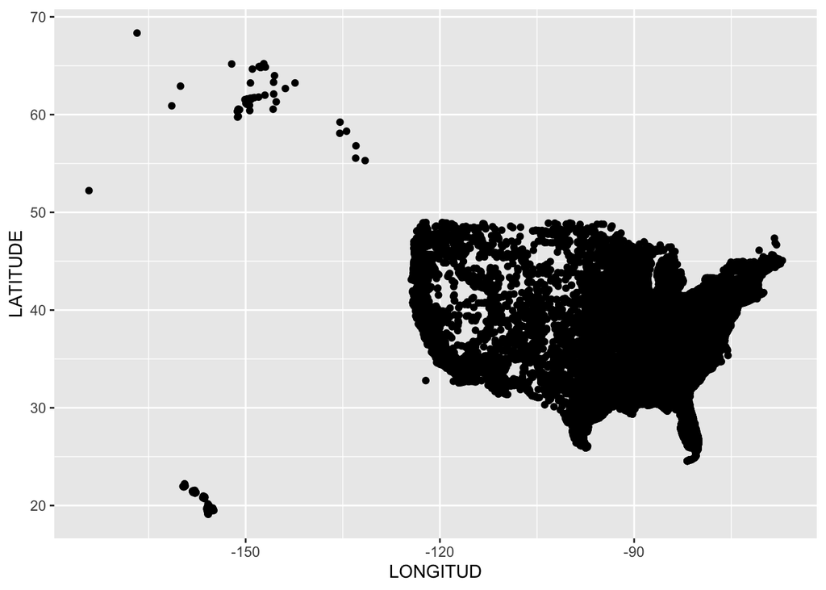

```r
accident_filter = dplyr::filter(accident, LONGITUD<500)
ggplot(accident_filter, aes(x=LONGITUD, y=LATITUDE)) + geom_point()
```

# Days of the week

are there some days of the week where more accidents happen than on others (use variable DAY_WEEK)? Assuming 1 is Sunday, it looks like accidents are increased on the weekends, and lower towards the middle of the week.

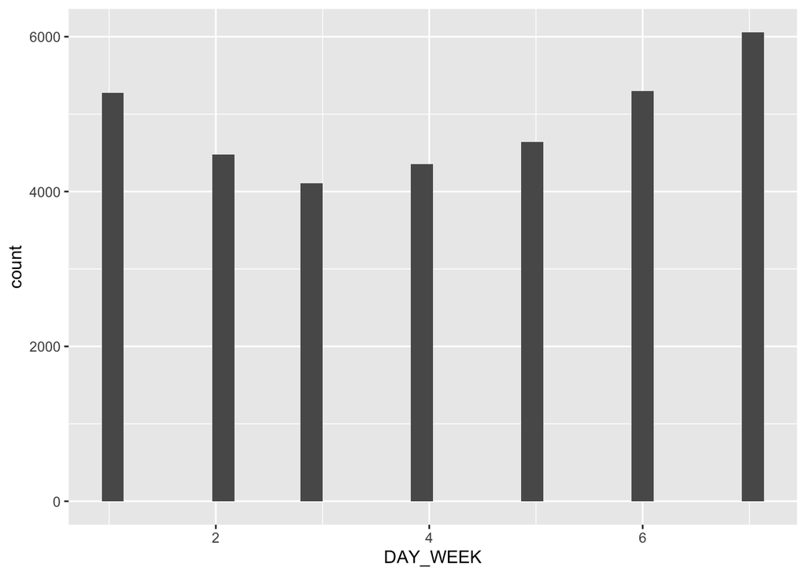

```r
ggplot(accident_filter, aes(x=DAY_WEEK) ) + geom_histogram()
```

# Time of the day

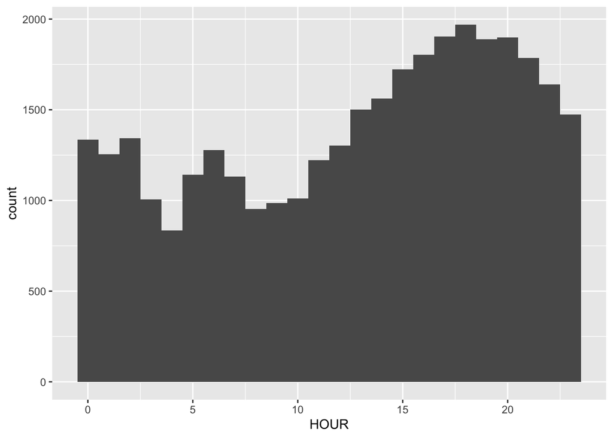

```r
accident_filter = dplyr::filter(accident_filter, HOUR<25)
ggplot(accident_filter, aes(x=HOUR) ) + geom_histogram(binwidth=1)
```

# Drunk Driving

what is the number of accidents with at least one drunk driver (use variable DRUNK_DR)? 8,720 accidents with at least one drunk driver

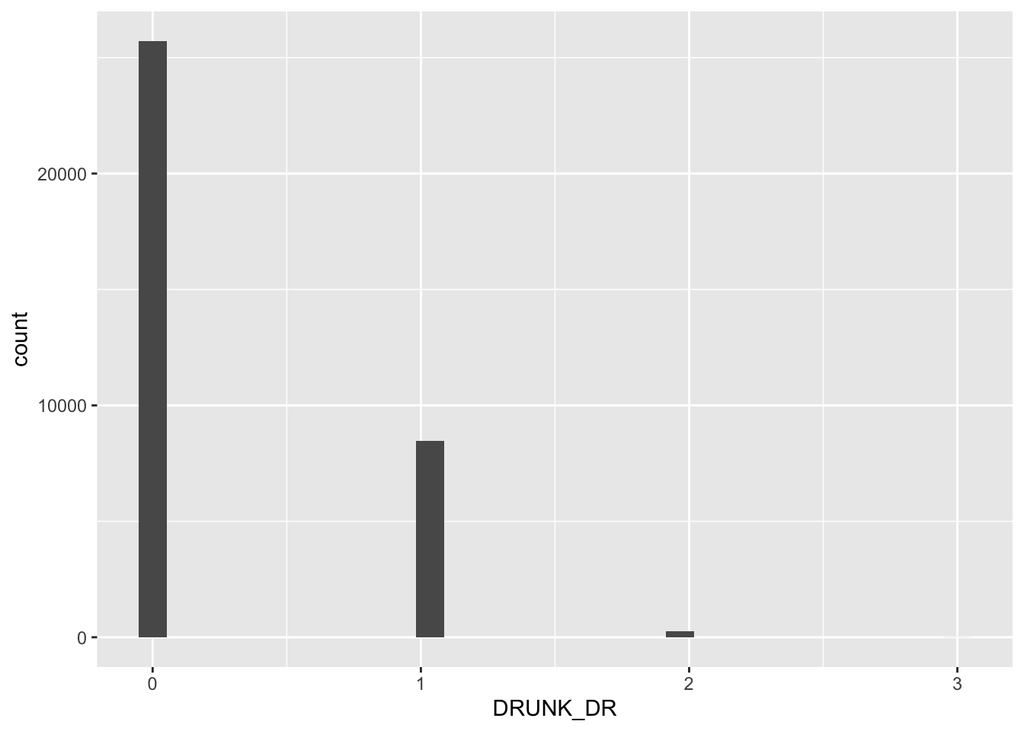

```r
ggplot(accident, aes(x=DRUNK_DR) ) + geom_histogram()
```

```r
nrow(dplyr::filter(accident, DRUNK_DR>0))
```

```
## [1] 8720
```

# Connecting Person and Accident

Connect to the person table. Identify drivers (PER_TYP == 1, see fars manual ) and subset on them.

Join accident and driver table (work out which variable(s) to use)

Tally the number of accidents by day of the week (DAY_WEEK), hour of the day (HOUR) and gender (SEX). Visualize the results!

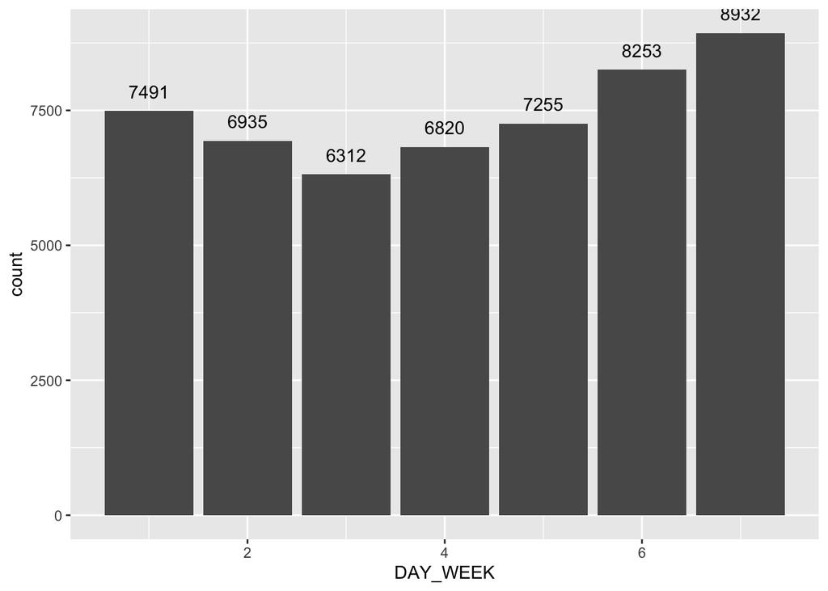

```r
drivers = dplyr::filter(person, PER_TYP == 1)
combo_data = left_join(accident, drivers, by="ST_CASE")


ggplot(combo_data, aes(x=DAY_WEEK) ) + geom_bar() +
geom_text(stat='count', aes(label=..count..), vjust=-1)
```

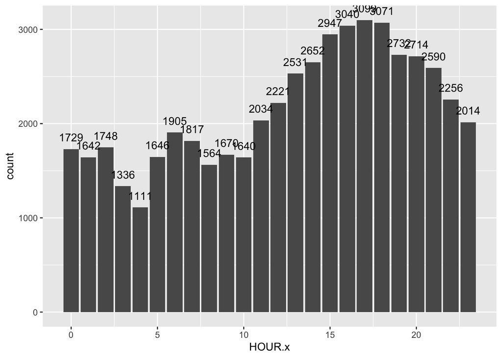

```r
combo_data_filter = dplyr::filter(combo_data, HOUR.x<25)
ggplot(combo_data_filter, aes(x=HOUR.x) ) + geom_bar()+
geom_text(stat='count', aes(label=..count..), vjust=-1)
```

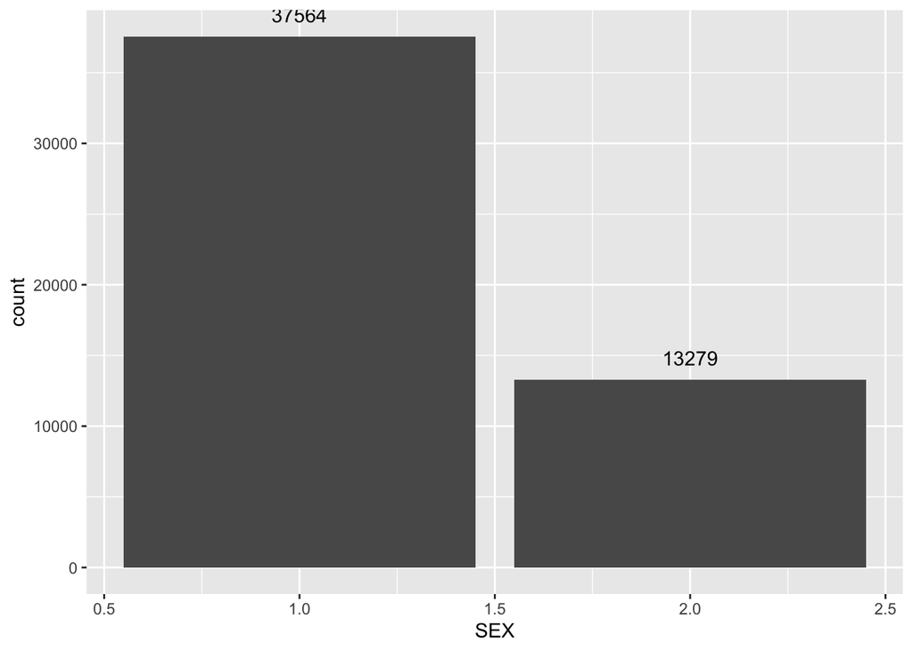

```r
combo_data_filter2 = dplyr::filter(combo_data, SEX<3)
ggplot(combo_data_filter2, aes(x=SEX)) + geom_bar()+
geom_text(stat='count', aes(label=..count..), vjust=-1)
```